# Using qnormGC()

# Comparison of `qnormGC()` with `pnormGC()`

The function `pnorm()` in regular `R`, as well as the function `pnormGC() in the`tigerstats` package, compute probabilities from known bounding values. For example, suppose that $X$ is a normally distributed random variable with mean 70 and standard deviation 3, and that you want to know:

$P(X < 72).$

Then you *know* the boundary value 72, but you don’t know the probability: the area under the normal density curve before 72. Functions like `pnormGC()` aim to give you that area–that probability:

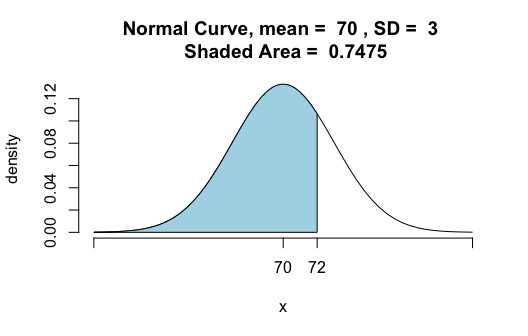

```
## [1] 0.7475075
```

```r
pnormGC(72, region="below", mean=70,
        sd=3,graph=TRUE)
```

The function `qnormGC()`aims to do the opposite: given an area, find the boundary value that determines this area.

For example, suppose you want to find that 85th percentile of a normal distribution whose mean is 70 and whose standard deviation is 3. Then you ask for:

```r
qnormGC(0.85,region="below",mean=70,sd=3)
```

```
## [1] 73.1093
```

The value 73.1093 is indeed the 85th percentile, in the sense that 85% of the values in a population that is normally distributed with mean 70 and standard deviation 3 will lie below 73.1093. In other words, if you were to pick a random member $X$ from such a population, then

$P(X < 73.1093) = 0.85$.

Quite often you will want to check your understanding by making a graph of the known percent, with the bounding percentile on the x-axis:

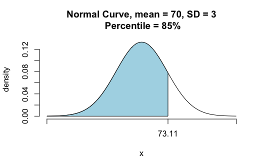

```
## [1] 73.1093
```

```r
qnormGC(0.85,region="below",mean=70,sd=3,graph=TRUE)
```

# A Few More Examples

## Making the Top Ten Percent (An Area Above)

> Suppose that SAT scores are normally distributed, and that the mean SAT score is 1000, and the standard deviation of all SAT scores is 100. *How high must you score so that only 10% of the population scores higher than you?*

Here’s the solution: just set `region` to “above”:

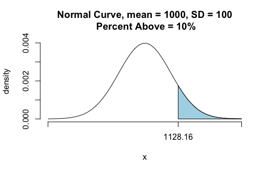

```
## [1] 1128.155
```

```r
qnormGC(0.10,region="above",mean=1000,sd=100,graph=TRUE)
```

In other words, the 90th percentile of SAT scores is around 1128.

Of course, you could have got the same thing by realizing that when 10% are above, 90% are below. Then you could just ask for:

```r
qnormGC(0.90,region="below",mean=1000,sd=100)
```

```
## [1] 1128.155
```

## An Area Between

> Find a positive number $z$ so that the area under the standard normal curve between $-z$ and $z$ is 0.95.

Here, we can set the `region` argument to “between”. The default value for `mean` is 0 and for `sd` the default is 1, so we can leave those arguments out if we like:

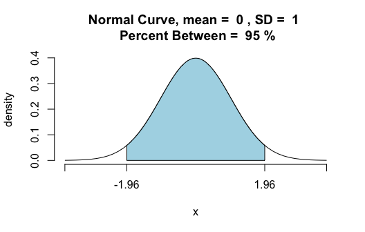

```
## [1] -1.959964  1.959964
```

```r
qnormGC(0.95,region="between",graph=TRUE)
```

Both bounds are given. The positive number we sought is about 1.96.

## An Area Outside

> Find a positive number $z$ so that the area under the standard normal curve before $-z$ plus the area after $z$ is 0.10.

Here, we can set the `region` argument to “outside”. The default value for `mean` is 0 and for `sd` the default is 1, so we can leave those arguments out if we like:

[figure not shown]

```
## [1] -1.644854  1.644854
```

```r
qnormGC(0.10,region="outside",graph=TRUE)
```

Both bounds are given. The positive number we sought is about 1.645.